# risk_plot

Abigail Tyrell

14 Jan 2021

# Risk ranking of Northeast stocks

## Methods

### Risk ranking

All stocks were ranked in order of increasing risk. The stock with the highest ranking is the stock determined to be at the highest risk. In this case, high risk has two meanings: (1) high importance (e.g., a stock with a high catch would have a high risk ranking for the catch indicator) or high vulnerability (e.g., a stock with low B/Bmsy would have a high risk ranking for the B/Bmsy indicator). The normalized rank was determined by dividing each stock’s rank by the total number of stocks considered for that indicator. Stocks that were missing indicator measurements were assigned a normalized rank of 0.5.

| Category | Indicator | Metric | Risk |
| --- | --- | --- | --- |
| Biological | avg_length_fall | Mean of past 10 years as a percent of the historical mean | Decrease is risky |
| Biological | avg_length_spring | Mean of past 10 years as a percent of the historical mean | Decrease is risky |
| Biological | max_length_fall | Mean of past 10 years as a percent of the historical mean | Decrease is risky |
| Biological | max_length_spring | Mean of past 10 years as a percent of the historical mean | Decrease is risky |
| Biological | diet | Number of prey categories from all time | Low is risky |
| Population | bbmsy | Most recent value | Low is risky |
| Population | recruitment | Mean of past 10 years as a percent of the historical mean | Decrease is risky |
| Population | asmt_abundance | Mean of past 10 years as a percent of the historical mean | Decrease is risky |
| Population | asmt_biomass | Mean of past 10 years as a percent of the historical mean | Decrease is risky |
| Population | biomass_fall | Mean of past 10 years as a percent of the historical mean | Decrease is risky |

[output cut: 12 more lines]

### Guilds

Guilds were determined from [previous reporting](https://repository.library.noaa.gov/view/noaa/5277). Guilds were further broken into small (<40cm) and large (>=40cm) size classes. To determine guild risk, the risk values for each species were averaged over all stock areas. Then risk values were averaged by guild. Guilds were ranked in each indicator category.

demersal_benthivore small

| Species | Scientific_name |
| --- | --- |
| Acadian redfish | *Sebastes fasciatus* |
| American plaice | *Hippoglossoides platessoides* |
| Haddock | *Melanogrammus aeglefinus* |
| Red hake | *Urophycis chuss* |
| Rosette skate | *Leucoraja garmani* |
| Scup | *Stenotomus chrysops* |
| Windowpane | *Scophthalmus aquosus* |
| Winter flounder | *Pseudopleuronectes americanus* |
| Witch flounder | *Glyptocephalus cynoglossus* |
| Yellowtail flounder | *Limanda ferruginea* |

demersal_benthivore large

| Species | Scientific_name |
| --- | --- |
| Atlantic wolffish | *Anarhichas lupus* |
| Clearnose skate | *Raja eglanteria* |
| Ocean pout | *Zoarces americanus* |
| Smooth skate | *Malacoraja senta* |

demersal_omnivore small

| Species | Scientific_name |
| --- | --- |
| Black sea bass | *Centropristis striata* |
| Little skate | *Leucoraja erinacea* |

demersal_omnivore large

| Species | Scientific_name |
| --- | --- |
| Barndoor skate | *Dipturus laevis* |
| Thorny skate | *Amblyraja radiata* |
| Winter skate | *Leucoraja ocellata* |

demersal_piscivore small

| Species | Scientific_name |
| --- | --- |
| Offshore hake | *Merluccius albidus* |
| Silver hake | *Merluccius bilinearis* |
| Summer flounder | *Paralichthys dentatus* |

demersal_piscivore large

| Species | Scientific_name |
| --- | --- |
| Atlantic cod | *Gadus morhua* |
| Atlantic halibut | *Hippoglossus hippoglossus* |
| Goosefish | *Lophius americanus* |
| Pollock | *Pollachius virens* |
| Smooth dogfish | *Mustelus canis* |
| Spiny dogfish | *Squalus acanthias* |
| White hake | *Urophycis tenuis* |

megabenthos small

| Species | Scientific_name |
| --- | --- |
| American lobster | *Homarus americanus* |
| Jonah crab | *Cancer borealis* |

pelagic small

| Species | Scientific_name |
| --- | --- |
| Alewife | *Alosa pseudoharengus* |
| Atlantic herring | *Clupea harengus* |
| Atlantic mackerel | *Scomber scombrus* |
| Blueback herring | *Alosa aestivalis* |
| Butterfish | *Peprilus triacanthus* |

## Results

### Stock risk

Ranks for all stocks.

#### Figures

The total risk (sum of all normalized risk values) is shown for each stock.

##### By region

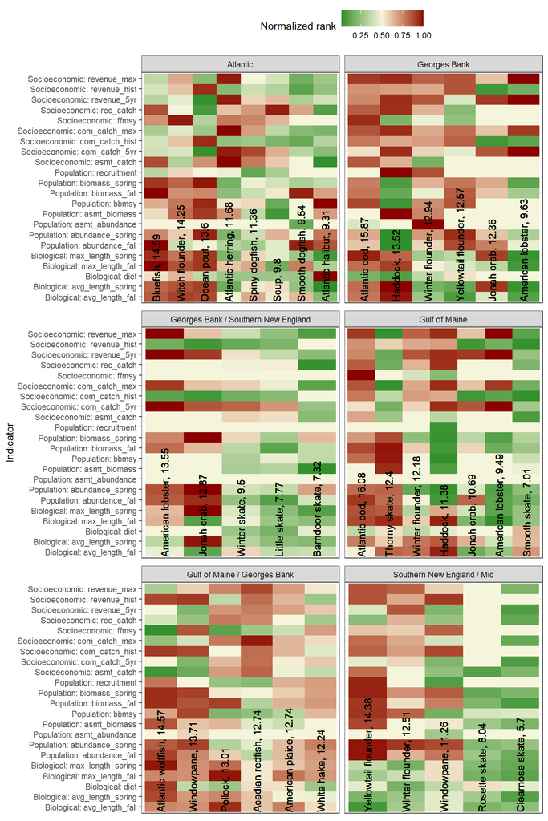

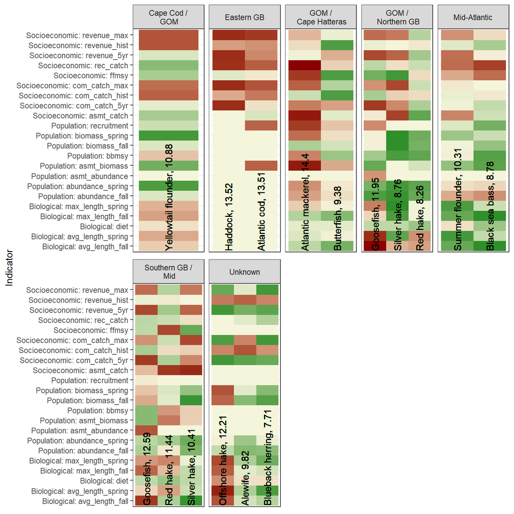

##### In order of risk

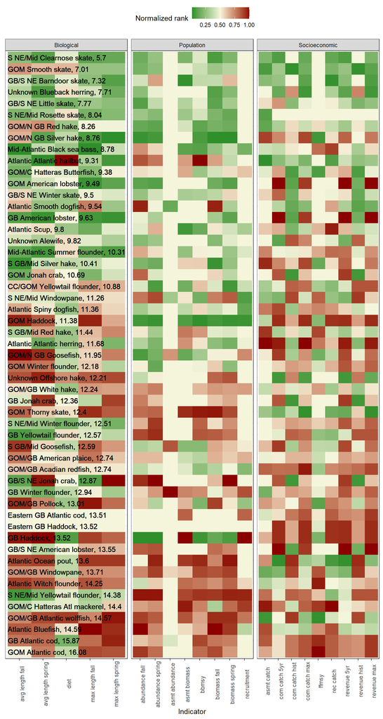

#### Data

##### All data

| Species | Region | Indicator | category | Year | Value | rank | n_stocks_per_indicator | n_stocks_per_region | norm_rank | total_risk | overall_rank | overall_stocks | new_label |
| --- | --- | --- | --- | --- | --- | --- | --- | --- | --- | --- | --- | --- | --- |
| Acadian redfish | Gulf of Maine / Georges Bank | bbmsy | Population | 2016 | 1.45 | 10 | 41 | 6 | 0.244 | 12.74 | 37 | 53 |  |
| Acadian redfish | Gulf of Maine / Georges Bank | ffmsy | Socioeconomic | 2016 | 0.28 | 10 | 36 | 6 | 0.278 | 12.74 | 37 | 53 |  |
| Acadian redfish | Gulf of Maine / Georges Bank | asmt_catch | Socioeconomic | 1942 | 55,892.00 | 33 | 40 | 6 | 0.825 | 12.74 | 37 | 53 |  |
| Acadian redfish | Gulf of Maine / Georges Bank | recruitment | Population | mean of last 10 years vs historic mean | 1.68 | 5 | 23 | 6 | 0.217 | 12.74 | 37 | 53 |  |
| Acadian redfish | Gulf of Maine / Georges Bank | asmt_abundance | Population |  | NA |  |  | 6 | 0.5 | 12.74 | 37 | 53 |  |
| Acadian redfish | Gulf of Maine / Georges Bank | asmt_biomass | Population | mean of last 10 years vs historic mean | 1.14 | 16 | 36 | 6 | 0.444 | 12.74 | 37 | 53 |  |
| Acadian redfish | Gulf of Maine / Georges Bank | biomass_fall | Population | mean of last 10 years vs historic mean | 2.14 | 17 | 51 | 6 | 0.333 | 12.74 | 37 | 53 |  |
| Acadian redfish | Gulf of Maine / Georges Bank | biomass_spring | Population | mean of last 10 years vs historic mean | 1.39 | 25 | 51 | 6 | 0.49 | 12.74 | 37 | 53 |  |
| Acadian redfish | Gulf of Maine / Georges Bank | abundance_fall | Population | mean of last 10 years vs historic mean | 2.53 | 18 | 51 | 6 | 0.353 | 12.74 | 37 | 53 |  |
| Acadian redfish | Gulf of Maine / Georges Bank | abundance_spring | Population | mean of last 10 years vs historic mean | 1.73 | 23 | 51 | 6 | 0.451 | 12.74 | 37 | 53 |  |

[output cut: 1156 more lines]

##### Total risk only

| Species | Region | total_risk | overall_rank |
| --- | --- | --- | --- |
| Acadian redfish | Gulf of Maine / Georges Bank | 12.74 | 37 |
| American plaice | Gulf of Maine / Georges Bank | 12.74 | 36 |
| Atlantic cod | Georges Bank | 15.87 | 52 |
| Atlantic cod | Gulf of Maine | 16.08 | 53 |
| Atlantic halibut | Atlantic | 9.31 | 10 |
| Atlantic herring | Atlantic | 11.68 | 26 |
| Atlantic mackerel | Gulf of Maine / Cape Hatteras | 14.4 | 49 |
| Atlantic wolffish | Gulf of Maine / Georges Bank | 14.57 | 50 |
| Barndoor skate | Georges Bank / Southern New England | 7.32 | 3 |
| Black sea bass | Mid-Atlantic | 8.78 | 9 |

[output cut: 43 more lines]

### Guild risk

#### Figure

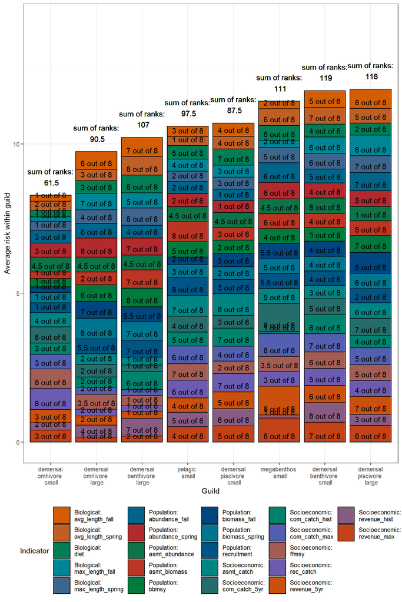

#### Data

| Guild | n_guild_species | category | Indicator | avg_guild_risk | rank | norm_rank | total_guild_risk | sum_ranks |
| --- | --- | --- | --- | --- | --- | --- | --- | --- |
| demersal_benthivore large | 4 | Biological | avg_length_fall | 0.64 | 7 | 0.875 | 10.22 | 107 |
| demersal_benthivore small | 10 | Biological | avg_length_fall | 0.56 | 5 | 0.625 | 11.79 | 119 |
| demersal_omnivore large | 3 | Biological | avg_length_fall | 0.59 | 6 | 0.75 | 9.74 | 90.5 |
| demersal_omnivore small | 2 | Biological | avg_length_fall | 0.20 | 1 | 0.125 | 8.28 | 61.5 |
| demersal_piscivore large | 7 | Biological | avg_length_fall | 0.65 | 8 | 1 | 11.84 | 118 |
| demersal_piscivore small | 3 | Biological | avg_length_fall | 0.45 | 4 | 0.5 | 10.7 | 87.5 |
| megabenthos small | 2 | Biological | avg_length_fall | 0.25 | 2 | 0.25 | 11.43 | 111 |
| pelagic small | 5 | Biological | avg_length_fall | 0.35 | 3 | 0.375 | 10.6 | 97.5 |
| demersal_benthivore large | 4 | Biological | avg_length_spring | 0.63 | 8 | 1 | 10.22 | 107 |
| demersal_benthivore small | 10 | Biological | avg_length_spring | 0.56 | 7 | 0.875 | 11.79 | 119 |

[output cut: 166 more lines]